# AllLife Bank Customer Segmentation

## Context

AllLife Bank wants to focus on its credit card customer base in the next financial year. They have been advised by their marketing research team, that the penetration in the market can be improved. Based on this input, the Marketing team proposes to run personalized campaigns to target new customers as well as upsell to existing customers. Another insight from the market research was that the customers perceive the support services of the back poorly. Based on this, the Operations team wants to upgrade the service delivery model, to ensure that customer queries are resolved faster. Head of Marketing and Head of Delivery both decide to reach out to the Data Science team for help

## Objective

To identify different segments in the existing customer, based on their spending patterns as well as past interaction with the bank, using clustering algorithms, and provide recommendations to the bank on how to better market to and service these customers.

## Data Dictionary

- Sl_No: Primary key of the records
- Customer Key: Customer identification number
- Average Credit Limit: Average credit limit of each customer for all credit cards
- Total credit cards: Total number of credit cards possessed by the customer
- Total visits bank: Total number of visits that customer made (yearly) personally to the bank
- Total visits online: Total number of visits or online logins made by the customer (yearly)
- Total calls made: Total number of calls made by the customer to the bank or its customer service department (yearly)

## 1. Initial Analysis / Structure of the Data

### Import Libraries

```python
# this will help in making the Python code more structured automatically (good coding practice)
%load_ext nb_black

# Libraries to help with reading and manipulating data
import pandas as pd
import numpy as np

# Libraries to help with data visualization
import matplotlib.pyplot as plt
import seaborn as sns

%matplotlib inline

# to scale the data
from sklearn.preprocessing import StandardScaler
from scipy.stats import zscore

# to compute distances
from scipy.spatial.distance import cdist

# to perform k-means clustering and compute silhouette scores
from sklearn.cluster import KMeans
from sklearn.metrics import silhouette_score

# to visualize the elbow curve and silhouette scores
from yellowbrick.cluster import KElbowVisualizer, SilhouetteVisualizer
from sklearn.cluster import AgglomerativeClustering
from scipy.cluster.hierarchy import cophenet, dendrogram, linkage
from scipy.spatial.distance import pdist  # Pairwise distribution between data points
from sklearn.linear_model import LinearRegression
from sklearn.decomposition import PCA

# To supress warnings
import warnings

warnings.filterwarnings("ignore")
```

```
The nb_black extension is already loaded. To reload it, use:
  %reload_ext nb_black
```

### Read The Dataset

```python
bank = pd.read_excel("Credit+Card+Customer+Data.xlsx")
```

### Checking the number of rows and columns

```python
# Checking the number of rows and columns in the data
bank.shape
```

```
(660, 7)
```

Observation:

- The dataset has 660 rows and 7 columns

```python
# Copying the data to another variable to avoid any changes to originl data
data = bank.copy()
```

### Viewing the first 5 and last 5 rows of the dataset

```python
data.head()
```

|  | Sl_No | Customer Key | Avg_Credit_Limit | Total_Credit_Cards | Total_visits_bank | Total_visits_online | Total_calls_made |
| --- | --- | --- | --- | --- | --- | --- | --- |
| 0 | 1 | 87073 | 100000 | 2 | 1 | 1 | 0 |
| 1 | 2 | 38414 | 50000 | 3 | 0 | 10 | 9 |
| 2 | 3 | 17341 | 50000 | 7 | 1 | 3 | 4 |
| 3 | 4 | 40496 | 30000 | 5 | 1 | 1 | 4 |
| 4 | 5 | 47437 | 100000 | 6 | 0 | 12 | 3 |

```python
data.tail()
```

|  | Sl_No | Customer Key | Avg_Credit_Limit | Total_Credit_Cards | Total_visits_bank | Total_visits_online | Total_calls_made |
| --- | --- | --- | --- | --- | --- | --- | --- |
| 655 | 656 | 51108 | 99000 | 10 | 1 | 10 | 0 |
| 656 | 657 | 60732 | 84000 | 10 | 1 | 13 | 2 |
| 657 | 658 | 53834 | 145000 | 8 | 1 | 9 | 1 |
| 658 | 659 | 80655 | 172000 | 10 | 1 | 15 | 0 |
| 659 | 660 | 80150 | 167000 | 9 | 0 | 12 | 2 |

### Check the datatyes of columns

```python
data.info()
```

```
<class 'pandas.core.frame.DataFrame'>
RangeIndex: 660 entries, 0 to 659
Data columns (total 7 columns):
 #   Column               Non-Null Count  Dtype
---  ------               --------------  -----
 0   Sl_No                660 non-null    int64
 1   Customer Key         660 non-null    int64
 2   Avg_Credit_Limit     660 non-null    int64
 3   Total_Credit_Cards   660 non-null    int64
 4   Total_visits_bank    660 non-null    int64
 5   Total_visits_online  660 non-null    int64
 6   Total_calls_made     660 non-null    int64
dtypes: int64(7)
memory usage: 36.2 KB
```

Observation

- Dataset has 660 rows and 7 columns
- All Columns have datatype as Numeric (int64)

### Check for Null values / Unique values / Duplicate rows

```python
data.duplicated().sum()
```

```
0
```

Observation

- There are no duplicate rows

```python
# checking for missing values
data.isna().sum()
```

```
Sl_No                  0
Customer Key           0
Avg_Credit_Limit       0
Total_Credit_Cards     0
Total_visits_bank      0
Total_visits_online    0
Total_calls_made       0
dtype: int64
```

```python
# let's check for missing values in the data
round(data.isnull().sum() / data.isnull().count() * 100, 2)
```

```
Sl_No                  0.0
Customer Key           0.0
Avg_Credit_Limit       0.0
Total_Credit_Cards     0.0
Total_visits_bank      0.0
Total_visits_online    0.0
Total_calls_made       0.0
dtype: float64
```

Observation:

```
* There are no null values in the dataset
```

```python
# Let's see unique values
cols = data.columns

for col in cols:
    print("Unique values in the column '{}' are \n\n".format(col), data[col].unique())
    print("-" * 100)
```

[output not shown]

[output cut: 113 more lines]

```python
# let's view the statistical summary of the numerical columns in the data
data.describe().T
```

|  | count | mean | std | min | 25% | 50% | 75% | max |
| --- | --- | --- | --- | --- | --- | --- | --- | --- |
| Sl_No | 660.0 | 330.500000 | 190.669872 | 1.0 | 165.75 | 330.5 | 495.25 | 660.0 |
| Customer Key | 660.0 | 55141.443939 | 25627.772200 | 11265.0 | 33825.25 | 53874.5 | 77202.50 | 99843.0 |
| Avg_Credit_Limit | 660.0 | 34574.242424 | 37625.487804 | 3000.0 | 10000.00 | 18000.0 | 48000.00 | 200000.0 |
| Total_Credit_Cards | 660.0 | 4.706061 | 2.167835 | 1.0 | 3.00 | 5.0 | 6.00 | 10.0 |
| Total_visits_bank | 660.0 | 2.403030 | 1.631813 | 0.0 | 1.00 | 2.0 | 4.00 | 5.0 |
| Total_visits_online | 660.0 | 2.606061 | 2.935724 | 0.0 | 1.00 | 2.0 | 4.00 | 15.0 |
| Total_calls_made | 660.0 | 3.583333 | 2.865317 | 0.0 | 1.00 | 3.0 | 5.00 | 10.0 |

Observation:

## Summary of Dataset

- Dataset has 660 rows and 7 columns
- All Columns have datatype as Numeric (int64)
- There are no duplicate rows
- There are no null values in the dataset
- Avg_Credit_limit column has a mean value of 34k, 75% of them has around 48k, but min is 3k, and the max is 200k. So this column has outliers.
- Total_Credit_Cards ranges from 1 to 10
- Total_visits_bank ranges from 0 to 5
- Total_visits_online ranges from 0 to 15
- Total_calls_made ranges from 0 to 10

## 2 Data Pre-Processing

```python
# Dropping Sl_No has it is a id column, which has no bearing on the analysis
data.drop(columns=["Sl_No"], inplace=True)
```

```python
data.duplicated().sum()
```

```
0
```

#### Analysis for "Customer Key" data

```python
data["Customer Key"].value_counts()
```

```
50706    2
37252    2
97935    2
96929    2
47437    2
        ..
58708    1
92501    1
33110    1
92503    1
75775    1
Name: Customer Key, Length: 655, dtype: int64
```

```python
data[data[["Customer Key"]].duplicated() == True]
```

|  | Customer Key | Avg_Credit_Limit | Total_Credit_Cards | Total_visits_bank | Total_visits_online | Total_calls_made |
| --- | --- | --- | --- | --- | --- | --- |
| 332 | 47437 | 17000 | 7 | 3 | 1 | 0 |
| 398 | 96929 | 67000 | 6 | 2 | 2 | 2 |
| 432 | 37252 | 59000 | 6 | 2 | 1 | 2 |
| 541 | 50706 | 60000 | 7 | 5 | 2 | 2 |
| 632 | 97935 | 187000 | 7 | 1 | 7 | 0 |

Observation

- There are duplicate values of Customer Key column (5 sets)
- The duplicate values might correspond to customer profile changes, and as such, there is no need to delete these records as these are actual occurrences at some point in the time. The column can be dropped during the analysis. **(Assumption)**

```python
# Dropping Customer Key columns as it is assumed that it has no bearing on the clustering analysis
data.drop(columns=["Customer Key"], inplace=True)
```

Observation

- Columns Sl_No and Customer Key columns are dropped as they so not have any bearing on the cluster analysis

#### Outlier Treatment

- It is assumed that outliers can form separate segments which could be useful for the business. **(Assumption)**.
- So in the ininital analysis we are not treating the outliers for Average_Credit_limit or Total_Visits_Online

# 3 EDA

### Univariate Analysis

```python
# function to plot a boxplot and a histogram along the same scale.


def histogram_boxplot(data, feature, figsize=(12, 7), kde=False, bins=None):
    """
    Boxplot and histogram combined

    data: dataframe
    feature: dataframe column
    figsize: size of figure (default (12,7))
    kde: whether to the show density curve (default False)
    bins: number of bins for histogram (default None)
    """
    f2, (ax_box2, ax_hist2) = plt.subplots(
        nrows=2,  # Number of rows of the subplot grid= 2
        sharex=True,  # x-axis will be shared among all subplots
        gridspec_kw={"height_ratios": (0.25, 0.75)},
        figsize=figsize,
    )  # creating the 2 subplots
    sns.boxplot(
        data=data, x=feature, ax=ax_box2, showmeans=True, color="violet"
    )  # boxplot will be created and a star will indicate the mean value of the column
    sns.histplot(
        data=data, x=feature, kde=kde, ax=ax_hist2, bins=bins, palette="winter"
    ) if bins else sns.histplot(
        data=data, x=feature, kde=kde, ax=ax_hist2
    )  # For histogram
    ax_hist2.axvline(
        data[feature].mean(), color="green", linestyle="--"
    )  # Add mean to the histogram
    ax_hist2.axvline(
        data[feature].median(), color="black", linestyle="-"
    )  # Add median to the histogram
```

```python
# function to create labeled barplots


def labeled_barplot(data, feature, perc=False, n=None):
    """
    Barplot with percentage at the top

    data: dataframe
    feature: dataframe column
    perc: whether to display percentages instead of count (default is False)
    n: displays the top n category levels (default is None, i.e., display all levels)
    """

    total = len(data[feature])  # length of the column
    count = data[feature].nunique()
    if n is None:
        plt.figure(figsize=(count + 2, 6))
    else:
        plt.figure(figsize=(n + 2, 6))

    plt.xticks(rotation=90, fontsize=15)
    ax = sns.countplot(
        data=data,
        x=feature,
        palette="Paired",
        order=data[feature].value_counts().index[:n].sort_values(),
    )

    for p in ax.patches:
        if perc == True:
            label = "{:.1f}%".format(
                100 * p.get_height() / total
            )  # percentage of each class of the category
        else:
            label = p.get_height()  # count of each level of the category

        x = p.get_x() + p.get_width() / 2  # width of the plot
        y = p.get_height()  # height of the plot

        ax.annotate(
            label,
            (x, y),
            ha="center",
            va="center",
            size=12,
            xytext=(0, 5),
            textcoords="offset points",
        )  # annotate the percentage

    plt.show()  # show the plot
```

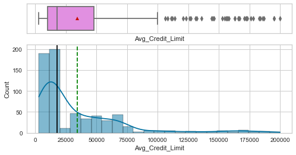

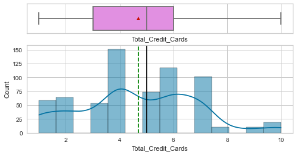

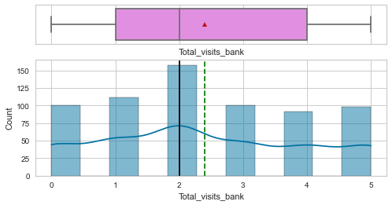

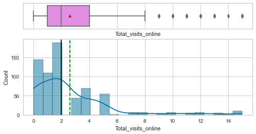

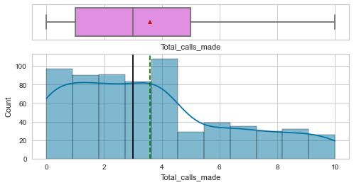

```python
# selecting numerical columns
num_col = data.select_dtypes(include=np.number).columns.tolist()

for item in num_col:
    histogram_boxplot(data, item, kde=True, figsize=(8, 4))
```

Observation

- Average Credit Limit is a heavy right skewed column. There are many outliers. The majority of customers are between 3k to 25k.
- There is a large segment of customers who have 4 credit cards.
- Total_visits_bank is somewhat evenly distributed.
- Total_visits_online for majority of customers is between 0 and 2, but there are some outliers here some go upt 15 visits
- Total_calls_made is also a right skewed as most of the customers made around 4 calls

### Observation on Total Number of Credit Cards

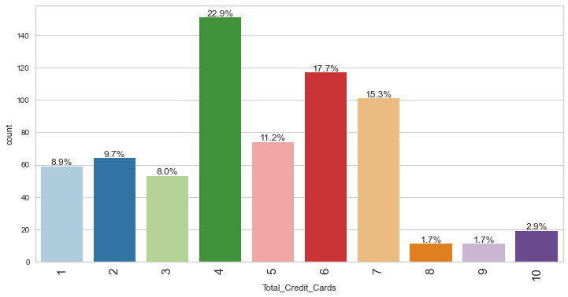

```python
labeled_barplot(data, "Total_Credit_Cards", perc=True)
```

Observation

- Around 23% of customers have 4 credit cards followed by 18% of customers have 6. There is around 3% of customers whch have 10 credit cards (max)

### Observation on Total number of Bank Visits

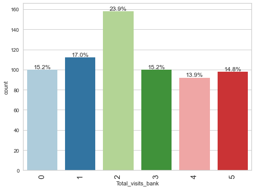

```python
labeled_barplot(data, "Total_visits_bank", perc=True)
```

Observation

- Around 24% of Customers pay around 2 visits (majority)
- There are around 15% of customers who do not visit the bank at all
- There are around 15% if customers who have visited 5 times (max)

### Observation on Total number of Visits Online

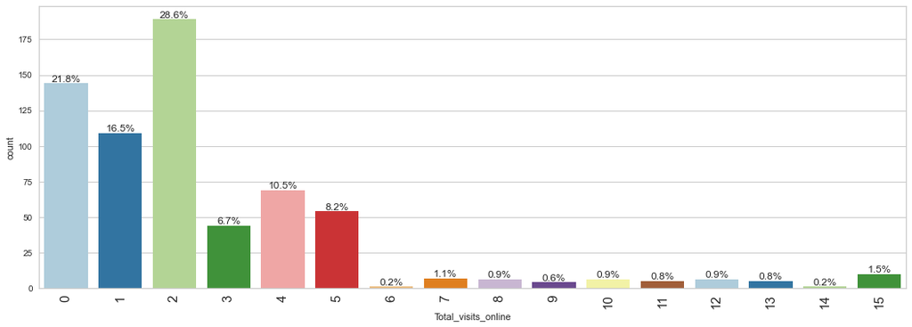

```python
labeled_barplot(data, "Total_visits_online", perc=True)
```

Observation

### Observation on Total Calls made

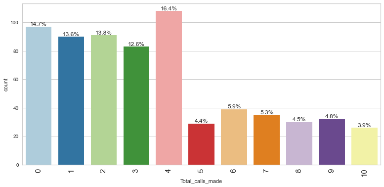

```python
labeled_barplot(data, "Total_calls_made", perc=True)
```

Observation

- There are around 15% customers who have not made any calls
- The max calls made segment is around 16%, is 4 calls.
- Majority of Customers (70%) make around 0-4 calls.

## Bivariate Analysis

### Correlation Plot

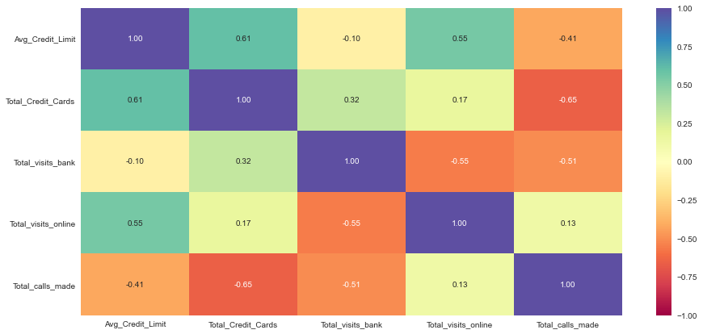

```python
plt.figure(figsize=(15, 7))
sns.heatmap(data.corr(), annot=True, vmin=-1, vmax=1, fmt=".2f", cmap="Spectral")
plt.show()
```

Observation

- The highest correlation (0.61) is between Total_Credit_Cards and Avg_Credt_limit (this is kind of understandable as higher the Credit Limit is a pre-requisite to higher number of Credit Cards)
- There is a negative correlation between (-0.65) between Total_Credit_Cards and Total_Calls_Made
- There is a negative correlation between (-0.55) between Total_visits_bank and Total_visits_online (This could be due to online customers are not visiting the bank as much )

### PairPlot

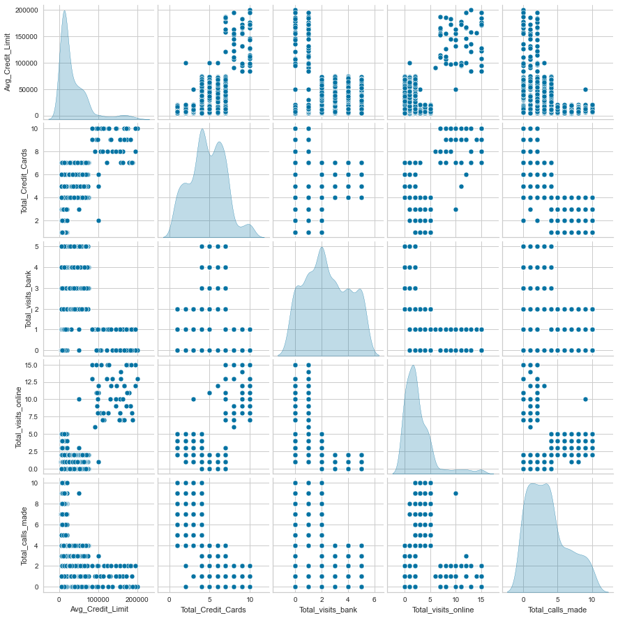

```python
sns.pairplot(data, diag_kind="kde")
plt.show()
```

Observations

- None of the features appear to be uniformly distribued
- All features distribution are multi-modal (multiple peaks)

### Summary of EDA

Average Credit Limit is a heavy right skewed column. There are many outliers. The majority of customers are between 3k to 25k. There is a large segment of customers who have 4 credit cards. Total_visits_bank is somewhat evenly distributed. Total_visits_online for majority of customers is between 0 and 2, but there are some outliers here some go upt 15 visits Total_calls_made is also a right skewed as most of the customers made around 4 calls

Around 23% of customers have 4 credit cards followed by 18% of customers have 6. There is around 3% of customers whch have 10 credit cards (max)

Around 24% of Customers pay around 2 visits (majority) There are around 15% of customers who do not visit the bank at all There are around 15% if customers who have visited 5 times (max)

There are around 15% customers who have not made any calls The max calls made segment is around 16%, is 4 calls. Majority of Customers (70%) make around 0-4 calls.

The highest correlation (0.61) is between Total_Credit_Cards and Avg_Credt_limit (this is kind of understandable as higher the Credit Limit is a pre-requisite to higher number of Credit Cards) There is a negative correlation between (-0.65) between Total_Credit_Cards and Total_Calls_Made There is a negative correlation between (-0.55) between Total_visits_bank and Total_visits_online (This could be due to online customers are not visiting the bank as much )

### Scaling the dataset before clustering and creating a dataframe

```python
scaler = StandardScaler()
data_scaled = scaler.fit_transform(data)
```

```python
# Creating a dataframe from the scaled data
scaled_df = pd.DataFrame(data_scaled, columns=data.columns)
```

```python
scaled_df.head()
```

|  | Avg_Credit_Limit | Total_Credit_Cards | Total_visits_bank | Total_visits_online | Total_calls_made |
| --- | --- | --- | --- | --- | --- |
| 0 | 1.740187 | -1.249225 | -0.860451 | -0.547490 | -1.251537 |
| 1 | 0.410293 | -0.787585 | -1.473731 | 2.520519 | 1.891859 |
| 2 | 0.410293 | 1.058973 | -0.860451 | 0.134290 | 0.145528 |
| 3 | -0.121665 | 0.135694 | -0.860451 | -0.547490 | 0.145528 |
| 4 | 1.740187 | 0.597334 | -1.473731 | 3.202298 | -0.203739 |

### Copying dataframes (original and scaled) for hieracrchical clustering (used later in the notebook)

```python
# data_h is the copy of original data to be used in hierachichal clustering
# scaled_df_h is the copy of scaled data to be used in hierachichal clustering
data_h = data.copy()
scaled_df_h = scaled_df.copy()
```

## 4 K-means Clustering

#### Grouping data into similar clusters

```
Number of Clusters: 1 	Average Distortion: 2.0069222262503614
Number of Clusters: 2 	Average Distortion: 1.4571553548514269
Number of Clusters: 3 	Average Distortion: 1.1466276549150365
Number of Clusters: 4 	Average Distortion: 1.0463825294774465
Number of Clusters: 5 	Average Distortion: 0.9908683849620168
Number of Clusters: 6 	Average Distortion: 0.9430693962124551
Number of Clusters: 7 	Average Distortion: 0.9091362001500471
Number of Clusters: 8 	Average Distortion: 0.8834985622675884
```

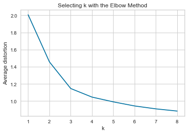

```python
clusters = range(1, 9)
meanDistortions = []

for k in clusters:
    model = KMeans(n_clusters=k)
    model.fit(scaled_df)
    prediction = model.predict(scaled_df)
    distortion = (
        sum(np.min(cdist(scaled_df, model.cluster_centers_, "euclidean"), axis=1))
        / scaled_df.shape[0]
    )

    meanDistortions.append(distortion)

    print("Number of Clusters:", k, "\tAverage Distortion:", distortion)

plt.plot(clusters, meanDistortions, "bx-")
plt.xlabel("k")
plt.ylabel("Average distortion")
plt.title("Selecting k with the Elbow Method")
plt.show()
```

Observation

- The elbow formation is can be observed at 2 as well as on 3 #### The appropriate value of k from the elbow curve seems to be 2 or 3

### Checking the Silhouette Scores

```
For n_clusters = 2, silhouette score is 0.41842496663215445
For n_clusters = 3, silhouette score is 0.5157182558881063
For n_clusters = 4, silhouette score is 0.3556670619372605
For n_clusters = 5, silhouette score is 0.2717470361089752
For n_clusters = 6, silhouette score is 0.25545029453623114
For n_clusters = 7, silhouette score is 0.2482471690924318
For n_clusters = 8, silhouette score is 0.22627429362568843
For n_clusters = 9, silhouette score is 0.21918848230227575
```

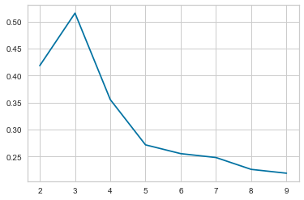

```python
sil_score = []
cluster_list = list(range(2, 10))
for n_clusters in cluster_list:
    clusterer = KMeans(n_clusters=n_clusters)
    preds = clusterer.fit_predict((scaled_df))
    # centers = clusterer.cluster_centers_
    score = silhouette_score(scaled_df, preds)
    sil_score.append(score)
    print("For n_clusters = {}, silhouette score is {}".format(n_clusters, score))

plt.plot(cluster_list, sil_score)
```

Observation

- For n_clusters = 3, silhouette score is 0.5157182558881063, is the highest value observed amongs other values.

#### Visualizing with Number of Clusters =3

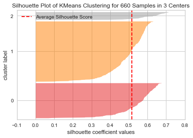

```python
# finding optimal no. of clusters with silhouette coefficients
visualizer = SilhouetteVisualizer(KMeans(3, random_state=1))
visualizer.fit(scaled_df)
visualizer.show()
```

Observation

- It is observed that Clusters 0 and 1 are somewhat similar sized, 2 is having a relatively small number of count.
- The smaller count cluster probably will be of the upper outliers of the Avg_Credit_Limit

#### Visualizing with Number of Clusters =2

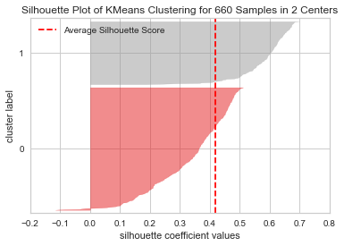

```python
# finding optimal no. of clusters with silhouette coefficients
visualizer = SilhouetteVisualizer(KMeans(2, random_state=1))
visualizer.fit(scaled_df)
visualizer.show()
```

Observations:

- It is observed that Cluster 0, is a larger one compared to cluster 1
- A small Part of the Cluster 0 graph is in the negative territory.

Based on the visualizations, and silhouette score, *it was decided 3 as a suitable value for n_clusters*

```python
kmeans = KMeans(n_clusters=3, random_state=0)
kmeans.fit(scaled_df)
```

```
KMeans(n_clusters=3, random_state=0)
```

```python
# adding kmeans cluster labels to the original dataframe
data["K_means_segments"] = kmeans.labels_
# adding kmeans cluster labels to the scaled dataframe
scaled_df["K_means_segments"] = kmeans.labels_
```

```python
scaled_df.head()
```

|  | Avg_Credit_Limit | Total_Credit_Cards | Total_visits_bank | Total_visits_online | Total_calls_made | K_means_segments |
| --- | --- | --- | --- | --- | --- | --- |
| 0 | 1.740187 | -1.249225 | -0.860451 | -0.547490 | -1.251537 | 0 |
| 1 | 0.410293 | -0.787585 | -1.473731 | 2.520519 | 1.891859 | 1 |
| 2 | 0.410293 | 1.058973 | -0.860451 | 0.134290 | 0.145528 | 0 |
| 3 | -0.121665 | 0.135694 | -0.860451 | -0.547490 | 0.145528 | 0 |
| 4 | 1.740187 | 0.597334 | -1.473731 | 3.202298 | -0.203739 | 2 |

### Cluster Profiling K-Means

```python
cluster_profile = data.groupby("K_means_segments").mean()
```

```python
cluster_profile["count_in_each_segment"] = (
    data.groupby("K_means_segments")["Avg_Credit_Limit"].count().values
)
```

```python
# let's display cluster profiles
cluster_profile.style.highlight_max(color="lightgreen", axis=0)
```

| K_means_segments | Avg_Credit_Limit | Total_Credit_Cards | Total_visits_bank | Total_visits_online | Total_calls_made | count_in_each_segment |
| --- | --- | --- | --- | --- | --- | --- |
| 0 | 33782.383420 | 5.515544 | 3.489637 | 0.981865 | 2.000000 | 386 |
| 1 | 12174.107143 | 2.410714 | 0.933036 | 3.553571 | 6.870536 | 224 |
| 2 | 141040.000000 | 8.740000 | 0.600000 | 10.900000 | 1.080000 | 50 |

Observation

- Of the 3 clusters , we can see that cluster(2) has segmented the customers with higher Avg_Credit_Limit, Total_Credit_Cards and Total_Visits_online. It has only 50 customers.
- Cluster(0) comes second in terms of Avg_Credit_Limit, and most of the customers do physical visits to the bank (around 3 times an year). This segment has 386 customers (highest).
- Cluster (1) has the lowest value for mean of Avg_Credit_limit, and also lowest value of Total_Credit_cards. These customers has made the highest number of calls to the bank.

### Analyze the distribution of the data among the 3 groups using box plot and bar diagram

```
array([[<AxesSubplot:title={'center':'Avg_Credit_Limit'}, xlabel='[K_means_segments]'>,
        <AxesSubplot:title={'center':'Total_Credit_Cards'}, xlabel='[K_means_segments]'>,
        <AxesSubplot:title={'center':'Total_calls_made'}, xlabel='[K_means_segments]'>,
        <AxesSubplot:title={'center':'Total_visits_bank'}, xlabel='[K_means_segments]'>],
       [<AxesSubplot:title={'center':'Total_visits_online'}, xlabel='[K_means_segments]'>,
        <AxesSubplot:>, <AxesSubplot:>, <AxesSubplot:>]], dtype=object)
```

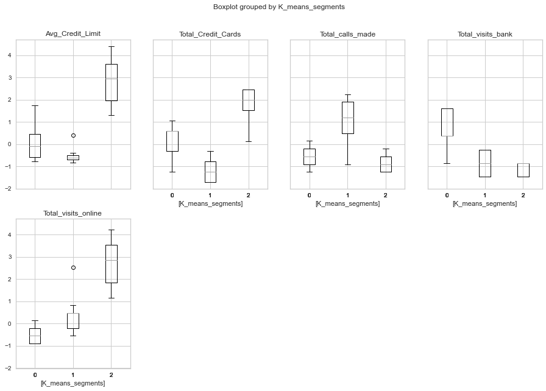

```python
scaled_df.boxplot(by="K_means_segments", layout=(2, 4), figsize=(15, 10))
```

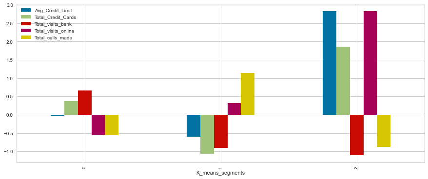

```python
scaled_df.groupby("K_means_segments").mean().plot.bar(figsize=(15, 6))
```

### Insights from K-Means Clusters

Each of the Clusters are showing significant variances from one another

**Cluster 0**

- This is the largest Cluster (386 Customers)
- Avg_Credit_Limit is mid-level compared to other clusters. (Avg is around ~33k)
- Customers of this segment visits the bank most

**Cluster 1**

- This is a mid size cluster with 224 customers
- Avg Credit Limit is the lowest for the customers of this cluster (Avg is around ~12k)
- This set of customers have made highest number of calls in average (~6 per year)
- Total number of credit cards is around 2

**Cluster 2**

- This is the smallest of the cluster with 50 customers (Most of these customers form the upper outliers in the credit limit)
- Avg Credit Limit for this segment is around 141k
- Number of Credit Cards is highest for this group (~8.7)
- This is the segment of customers which do online transactions (~10 times an year)

## 5 Hierachical Clustering

#### Calculating Cophenitic Correlation using various combination of distance metrics and linkage methods

```python
# list of distance metrics
# cityblock is same as manhattan
distance_metrics = ["euclidean", "chebyshev", "mahalanobis", "cityblock"]

# list of linkage methods
linkage_methods = ["single", "complete", "average", "weighted"]

high_cophenet_corr = 0
high_dm_lm = [0, 0]

for dm in distance_metrics:
    for lm in linkage_methods:
        Z = linkage(scaled_df_h, metric=dm, method=lm)
        c, coph_dists = cophenet(Z, pdist(scaled_df_h))
        print(
            "Cophenetic correlation for {} distance and {} linkage is {}.".format(
                dm.capitalize(), lm, c
            )
        )
        if high_cophenet_corr < c:
            high_cophenet_corr = c
            high_dm_lm[0] = dm
            high_dm_lm[1] = lm
```

```
Cophenetic correlation for Euclidean distance and single linkage is 0.7391220243806552.
Cophenetic correlation for Euclidean distance and complete linkage is 0.8599730607972423.
Cophenetic correlation for Euclidean distance and average linkage is 0.8977080867389372.
Cophenetic correlation for Euclidean distance and weighted linkage is 0.8861746814895477.
Cophenetic correlation for Chebyshev distance and single linkage is 0.7382354769296767.
Cophenetic correlation for Chebyshev distance and complete linkage is 0.8533474836336782.
Cophenetic correlation for Chebyshev distance and average linkage is 0.8974159511838106.
Cophenetic correlation for Chebyshev distance and weighted linkage is 0.8913624010768603.
Cophenetic correlation for Mahalanobis distance and single linkage is 0.7058064784553606.
Cophenetic correlation for Mahalanobis distance and complete linkage is 0.6663534463875361.
Cophenetic correlation for Mahalanobis distance and average linkage is 0.8326994115042136.
Cophenetic correlation for Mahalanobis distance and weighted linkage is 0.7805990615142518.
Cophenetic correlation for Cityblock distance and single linkage is 0.7252379350252723.
Cophenetic correlation for Cityblock distance and complete linkage is 0.8731477899179829.
Cophenetic correlation for Cityblock distance and average linkage is 0.896329431104133.
Cophenetic correlation for Cityblock distance and weighted linkage is 0.8825520731498188.
```

#### Finding the highest cophenetic correlation value

```python
# printing the combination of distance metric and linkage method with the highest cophenetic correlation
print(
    "Highest cophenetic correlation is {}, which is obtained with {} distance and {} linkage.".format(
        high_cophenet_corr, high_dm_lm[0].capitalize(), high_dm_lm[1]
    )
)
```

```
Highest cophenetic correlation is 0.8977080867389372, which is obtained with Euclidean distance and average linkage.
```

#### Trying different linkage methods and Euclidean (Ward method works only for Euclidean so trying this separately there)

```python
# list of linkage methods
linkage_methods = ["single", "complete", "average", "centroid", "ward", "weighted"]

high_cophenet_corr = 0
high_dm_lm = [0, 0]

for lm in linkage_methods:
    Z = linkage(scaled_df_h, metric="euclidean", method=lm)
    c, coph_dists = cophenet(Z, pdist(scaled_df_h))
    print("Cophenetic correlation for {} linkage is {}.".format(lm, c))
    if high_cophenet_corr < c:
        high_cophenet_corr = c
        high_dm_lm[0] = "euclidean"
        high_dm_lm[1] = lm
```

```
Cophenetic correlation for single linkage is 0.7391220243806552.
Cophenetic correlation for complete linkage is 0.8599730607972423.
Cophenetic correlation for average linkage is 0.8977080867389372.
Cophenetic correlation for centroid linkage is 0.8939385846326323.
Cophenetic correlation for ward linkage is 0.7415156284827493.
Cophenetic correlation for weighted linkage is 0.8861746814895477.
```

#### Finding the highest Cophenetic correlation value for various link methods and Euclidean distance metric

```python
# printing the combination of distance metric and linkage method with the highest cophenetic correlation
print(
    "Highest cophenetic correlation is {}, which is obtained with {} linkage.".format(
        high_cophenet_corr, high_dm_lm[1]
    )
)
```

```
Highest cophenetic correlation is 0.8977080867389372, which is obtained with average linkage.
```

Observation:

- In both cases, we were getting Highest Cophenetic Correlation of 0.897 with a combination of Euclidean and Average linkage

#### Draw Dendograms for Euclidean and various Linkage Methods

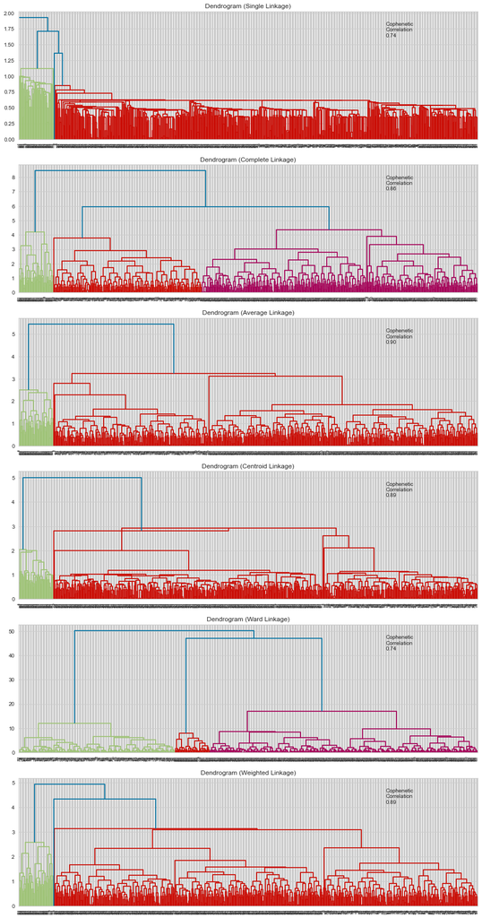

```python
# list of linkage methods
linkage_methods = ["single", "complete", "average", "centroid", "ward", "weighted"]

# lists to save results of cophenetic correlation calculation
compare_cols = ["Linkage", "Cophenetic Coefficient"]

# to create a subplot image
fig, axs = plt.subplots(len(linkage_methods), 1, figsize=(15, 30))

# We will enumerate through the list of linkage methods above
# For each linkage method, we will plot the dendrogram and calculate the cophenetic correlation
for i, method in enumerate(linkage_methods):
    Z = linkage(scaled_df_h, metric="euclidean", method=method)

    dendrogram(Z, ax=axs[i])
    axs[i].set_title(f"Dendrogram ({method.capitalize()} Linkage)")

    coph_corr, coph_dist = cophenet(Z, pdist(scaled_df_h))
    axs[i].annotate(
        f"Cophenetic\nCorrelation\n{coph_corr:0.2f}",
        (0.80, 0.80),
        xycoords="axes fraction",
    )
```

Observation

- Per various dendograms plotted on Euclidean distance, cophenetic correlation is highest 0.90 for Average linkage method.
- This is closely followed by Centroid and Weighted linkage (0.89)
- **2 or 3 would be appropriate number of clusters, as per the distinct clusters shown in the dendogram (Euclidean and Average Linkage)**

#### Verifying the number of Clusters during Silhouette Scores (euclidian and average)

```python
hc_model2 = AgglomerativeClustering(n_clusters = 2,affinity="euclidean", linkage="average")
hc_model3 = AgglomerativeClustering(n_clusters = 3,affinity="euclidean", linkage="average")
hc_model4 = AgglomerativeClustering(n_clusters = 4,affinity="euclidean", linkage="average")
hc_model5 = AgglomerativeClustering(n_clusters = 5,affinity="euclidean", linkage="average")
```

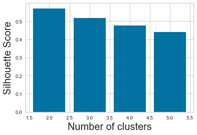

```python
k = [2, 3, 4, 5]

# Appending the silhouette scores of the different models to the list
silhouette_scores = []
silhouette_scores.append(
    silhouette_score(scaled_df_h, hc_model2.fit_predict(scaled_df_h))
)
silhouette_scores.append(
    silhouette_score(scaled_df_h, hc_model3.fit_predict(scaled_df_h))
)
silhouette_scores.append(
    silhouette_score(scaled_df_h, hc_model4.fit_predict(scaled_df_h))
)
silhouette_scores.append(
    silhouette_score(scaled_df_h, hc_model5.fit_predict(scaled_df_h))
)

plt.bar(k, silhouette_scores)
plt.xlabel("Number of clusters", fontsize=20)
plt.ylabel("Silhouette Score", fontsize=20)
plt.show()
```

#### Based on the bar diagram above, Silhouette Score is max for 2, but we would like to try clusters=3 , as we have some distinct outliers, so we Create 3 Clusters using Agglomerative Clustering

```python
# HCmodel = AgglomerativeClustering(n_clusters=3, affinity="euclidean", linkage="average")
hc_model3.fit(scaled_df_h)
```

```
AgglomerativeClustering(linkage='average', n_clusters=3)
```

```python
scaled_df_h["HC_Segments"] = hc_model3.labels_
data_h["HC_Segments"] = hc_model3.labels_
```

```python
scaled_df_h.head()
```

|  | Avg_Credit_Limit | Total_Credit_Cards | Total_visits_bank | Total_visits_online | Total_calls_made | HC_Segments |
| --- | --- | --- | --- | --- | --- | --- |
| 0 | 1.740187 | -1.249225 | -0.860451 | -0.547490 | -1.251537 | 0 |
| 1 | 0.410293 | -0.787585 | -1.473731 | 2.520519 | 1.891859 | 2 |
| 2 | 0.410293 | 1.058973 | -0.860451 | 0.134290 | 0.145528 | 0 |
| 3 | -0.121665 | 0.135694 | -0.860451 | -0.547490 | 0.145528 | 0 |
| 4 | 1.740187 | 0.597334 | -1.473731 | 3.202298 | -0.203739 | 1 |

#### Cluster Profiling - Hierachical Clustering

```python
cluster_profile = data_h.groupby("HC_Segments").mean()
```

```python
cluster_profile["count_in_each_segments"] = (
    data_h.groupby("HC_Segments")["Avg_Credit_Limit"].count().values
)
```

```python
# let's display cluster profiles
cluster_profile.style.highlight_max(color="lightgreen", axis=0)
```

| HC_Segments | Avg_Credit_Limit | Total_Credit_Cards | Total_visits_bank | Total_visits_online | Total_calls_made | count_in_each_segments |
| --- | --- | --- | --- | --- | --- | --- |
| 0 | 33713.178295 | 5.511628 | 3.485788 | 0.984496 | 2.005168 | 387 |
| 1 | 141040.000000 | 8.740000 | 0.600000 | 10.900000 | 1.080000 | 50 |
| 2 | 12197.309417 | 2.403587 | 0.928251 | 3.560538 | 6.883408 | 223 |

Observations

- Of the 3 clusters , we can see that cluster(1) has segmented the customers with higher Avg_Credit_Limit, Total_Credit_Cards and Total_Visits_online. It has only 50 customers.
- Cluster(0) comes second in terms of Avg_Credit_Limit, and most of the customers do physical visits to the bank (around 3 times an year). This segment has 387 customers (highest).
- Cluster (2) has the lowest value for mean of Avg_Credit_limit, and also lowest value of Total_Credit_cards. These customers has made the highest number of calls to the bank.

### Analyze the distribution of the data among the 3 groups using box plot and bar diagram

```
array([[<AxesSubplot:title={'center':'Avg_Credit_Limit'}, xlabel='[HC_Segments]'>,
        <AxesSubplot:title={'center':'Total_Credit_Cards'}, xlabel='[HC_Segments]'>,
        <AxesSubplot:title={'center':'Total_calls_made'}, xlabel='[HC_Segments]'>,
        <AxesSubplot:title={'center':'Total_visits_bank'}, xlabel='[HC_Segments]'>],
       [<AxesSubplot:title={'center':'Total_visits_online'}, xlabel='[HC_Segments]'>,
        <AxesSubplot:>, <AxesSubplot:>, <AxesSubplot:>]], dtype=object)
```

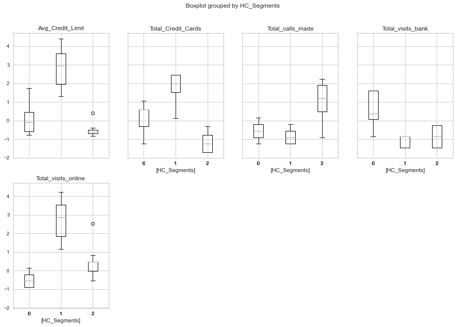

```python
scaled_df_h.boxplot(by="HC_Segments", layout=(2, 4), figsize=(15, 10))
```

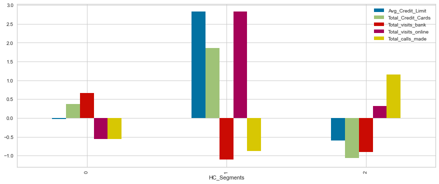

```python
scaled_df_h.groupby("HC_Segments").mean().plot.bar(figsize=(15, 6))
```

### Insights from Hierarchical Clusters

Each of the Clusters are showing distinct variances from one another

**Cluster 0**

- This is the largest Cluster (387 Customers)
- Avg_Credit_Limit is mid-level compared to other clusters. (Avg is around ~33k)
- Customers of this segment visits the bank most

**Cluster 1**

- This is the smallest of the cluster with 50 customers (Most of these customers are from the upper outliers in the credit limit)
- Avg Credit Limit for this segment is around 141k
- Number of Credit Cards is highest for this group (~8.7)
- This is the segment of customers which do online transactions (~11 times an year)

**Cluster 2**

- This is a mid size cluster with 223 customers
- Avg Credit Limit is the lowest for the customers of this cluster (Avg is around ~12k)
- This set of customers have made highest number of calls in average (~7 per year)
- Total number of credit cards is around 2

## 6 Comparison of K-Means and Hierarchical Clusters

**Time:** K-Means calculation is quick to execute in few seconds, Hierarchical took around 5 minutes for execution

**Distinct Clusters:** Both clustering methods gave very distinct clusters

**Silhouette Scores:** For K-Means , score was 0.51, for Hierachichal score was 0.51

**Number of Observations:** for both clusters, the number of customers (50) in the highest Avg_Credit_Limit was same. For other groups, it differed by 1. (386 vs 387, 224 vs 223)

## 7 Business Insights and Recommendations

- From the K-Means and Hierarchical Clustering techniques we have identified 3 distinct clusters of customers
- **Cluster-0** The majority class (386-387 customers) are with Mid Level Credit Limits (around 33k). Customers from this group visits the bank most.(physical visit)
- **Cluster-2** The next level is (223-224 customers), is a group with the lowest Credit Limit, (around 12k), they hold only 2 cards in average. Their interaction with bank is mostly thru call center.
- **Cluster-1** The smallest group of customers is for the third cluster (50 customers) , but they have the highest Credit Limit, and they have high number of credit Cards, and they transact with the bank online.

It is assumed that Online Transactions is the most cost effective way for the bank to interact with customers, compared to Physical Branch Visits and Call Centers.

To improve the service levels, Marketing team and Delivery team can reach to **Cluster-0** customers, who mostly visits the bank for their transactions to encourage them to use Online banking, which would be the most cost effective way for the bank.

Bank can reach **Cluster-1** group of customers, to understand the improvements needed for online offerrings, study the user friendliness of the applications. This group may be high tech-savvy, as they have the highest credit limits and highest number of cards. Since they are high yield customers, bank can also set up personalized banking experiences like Private Client Partnerships for business improvement.

Bank can target the **Cluster-2** customers which has the lowest Credit Limits, to offer newer products, encourage them to try online banking, by offerring incentives to use banking apps etc.

Service delivery teams, can target all these groups to analyze their scope of improvements for Online, Branch visit and Call Center experiences.